# Model Comparison (TRVB Cancer)

SK

June 25, 2019

## Models

### M0: Zero-model Binomial regression

- $Y_{ij} \sim \operatorname{Binomial}(N_{i}, \theta_{ij})$
- $\theta_{ij} = \operatorname{logit^{-1}} (\alpha_{j} + \beta_{j} \cdot X_{i})$
- $\beta_{j} \sim \operatorname{Normal}(\hat{\beta}, \hat{\beta}_{\sigma})$
- $\alpha_{j} \sim \operatorname{Normal}(\hat{\alpha}, \hat{\alpha}_{\sigma})$
- $\hat{\beta} \sim \operatorname{Normal}(0, 5)$
- $\hat{\alpha} \sim \operatorname{Normal}(0, 20)$
- $\beta_{\sigma}, \hat{\alpha}_{\sigma} \sim \operatorname{Cauchy^{+}}(0, 3)$

### M1: Binomial regression

- $Y_{ij} \sim \operatorname{Binomial}(N_{i}, \theta_{ij})$
- $\theta_{ij} = \operatorname{logit^{-1}} (\alpha_{j} + \beta_{ij} \cdot X_{i})$
- $\beta_{ij} \sim \operatorname{Normal}(\gamma_{j}, \gamma_{\sigma})$
- $\gamma_{j} \sim \operatorname{Normal}(\hat{\gamma}, \hat{\gamma}_{\sigma})$
- $\alpha_{j} \sim \operatorname{Normal}(\hat{\alpha}, \hat{\alpha}_{\sigma})$
- $\hat{\gamma} \sim \operatorname{Normal}(0, 5)$
- $\hat{\alpha} \sim \operatorname{Normal}(0, 20)$
- $\gamma_{\sigma}, \hat{\gamma}_{\sigma}, \hat{\alpha}_{\sigma} \sim \operatorname{Cauchy^{+}}(0, 3)$

### M2: Zero-Inflated-Binomial (ZIB) regression

- cases for $Y_{ij}=$
- $0, \text{with } \pi_j$
- $\operatorname{Binomial}(N_{i}, \theta_{ij}), \text{with } 1-\pi_j$
- $\theta_{ij} = \operatorname{logit^{-1}} (\alpha_{j} + \beta_{ij} \cdot X_{i})$
- $\beta_{ij} \sim \operatorname{Normal}(\gamma_{j}, \gamma_{\sigma})$
- $\gamma_{j} \sim \operatorname{Normal}(\hat{\gamma}, \hat{\gamma}_{\sigma})$
- $\alpha_{j} \sim \operatorname{Normal}(\hat{\alpha}, \hat{\alpha}_{\sigma})$
- $\hat{\gamma} \sim \operatorname{Normal}(0, 5)$
- $\hat{\alpha} \sim \operatorname{Normal}(0, 20)$
- $\gamma_{\sigma}, \hat{\gamma}_{\sigma}, \hat{\alpha}_{\sigma} \sim \operatorname{Cauchy^{+}}(0, 3)$
- $\pi_j \sim \operatorname{Beta}(1, 1)$

### M3: Beta-binomial regression

- $Y_{ij} \sim \operatorname{Beta-Binomial}(N_{i}, \theta_{ij} \cdot \phi, (1 - \theta_{ij}) \cdot \phi)$
- $\theta_{ij} = \operatorname{logit^{-1}} (\alpha_{j} + \beta_{ij} \cdot X_{i})$
- $\beta_{ij} \sim \operatorname{Normal}(\gamma_{j}, \gamma_{\sigma})$
- $\gamma_{j} \sim \operatorname{Normal}(\hat{\gamma}, \hat{\gamma}_{\sigma})$
- $\alpha_{j} \sim \operatorname{Normal}(\hat{\alpha}, \hat{\alpha}_{\sigma})$
- $\hat{\gamma} \sim \operatorname{Normal}(0, 5)$
- $\hat{\alpha} \sim \operatorname{Normal}(0, 20)$
- $\gamma_{\sigma}, \hat{\gamma}_{\sigma}, \hat{\alpha}_{\sigma} \sim \operatorname{Cauchy^{+}}(0, 3)$
- $\phi \sim \operatorname{Gamma}(0.1, 0.1)$

## LOO

### M0

```
FALSE
FALSE Computed from 6000 by 1536 log-likelihood matrix
FALSE
FALSE          Estimate SE
FALSE elpd_loo       NA NA
FALSE p_loo          NA NA
FALSE looic          NA NA
FALSE ------
FALSE Monte Carlo SE of elpd_loo is NA.
FALSE
FALSE Pareto k diagnostic values:
FALSE                          Count Pct.    Min. n_eff
FALSE (-Inf, 0.5]   (good)        0    0.0%  <NA>
FALSE  (0.5, 0.7]   (ok)          0    0.0%  <NA>
FALSE    (0.7, 1]   (bad)         0    0.0%  <NA>
FALSE    (1, Inf)   (very bad) 1536  100.0%  <NA>
FALSE See help('pareto-k-diagnostic') for details.
```

### M1

```
FALSE
FALSE Computed from 6000 by 1536 log-likelihood matrix
FALSE
FALSE          Estimate SE
FALSE elpd_loo       NA NA
FALSE p_loo          NA NA
FALSE looic          NA NA
FALSE ------
FALSE Monte Carlo SE of elpd_loo is NA.
FALSE
FALSE Pareto k diagnostic values:
FALSE                          Count Pct.    Min. n_eff
FALSE (-Inf, 0.5]   (good)       21   1.4%   115
FALSE  (0.5, 0.7]   (ok)         17   1.1%   72
FALSE    (0.7, 1]   (bad)       220  14.3%   16
FALSE    (1, Inf)   (very bad) 1278  83.2%   <NA>
FALSE See help('pareto-k-diagnostic') for details.
```

### M2

```
FALSE
FALSE Computed from 6000 by 1536 log-likelihood matrix
FALSE
FALSE          Estimate     SE
FALSE elpd_loo -16438.0  910.7
FALSE p_loo      7258.8  921.2
FALSE looic     32876.0 1821.4
FALSE ------
FALSE Monte Carlo SE of elpd_loo is NA.
FALSE
FALSE Pareto k diagnostic values:
FALSE                          Count Pct.    Min. n_eff
FALSE (-Inf, 0.5]   (good)       38   2.5%   238
FALSE  (0.5, 0.7]   (ok)         94   6.1%   92
FALSE    (0.7, 1]   (bad)      1001  65.2%   29
FALSE    (1, Inf)   (very bad)  403  26.2%   1
FALSE See help('pareto-k-diagnostic') for details.
```

### M3

```
FALSE
FALSE Computed from 6000 by 1536 log-likelihood matrix
FALSE
FALSE          Estimate    SE
FALSE elpd_loo -15300.4  70.3
FALSE p_loo      1044.3  17.8
FALSE looic     30600.7 140.7
FALSE ------
FALSE Monte Carlo SE of elpd_loo is NA.
FALSE
FALSE Pareto k diagnostic values:
FALSE                          Count Pct.    Min. n_eff
FALSE (-Inf, 0.5]   (good)     145    9.4%   653
FALSE  (0.5, 0.7]   (ok)       369   24.0%   158
FALSE    (0.7, 1]   (bad)      873   56.8%   18
FALSE    (1, Inf)   (very bad) 149    9.7%   3
FALSE See help('pareto-k-diagnostic') for details.
```

### Comparison

```
FALSE                                        elpd_diff se_diff  elpd_loo
FALSE loo::loo(loo::extract_log_lik(M3$glm))      0.0       0.0 -15300.4
FALSE loo::loo(loo::extract_log_lik(M2$glm))  -1137.6     927.8 -16438.0
FALSE loo::loo(loo::extract_log_lik(M0$glm))       NA        NA       NA
FALSE loo::loo(loo::extract_log_lik(M1$glm))       NA        NA       NA
FALSE                                        p_loo    looic
FALSE loo::loo(loo::extract_log_lik(M3$glm))   1044.3  30600.7
FALSE loo::loo(loo::extract_log_lik(M2$glm))   7258.8  32876.0
FALSE loo::loo(loo::extract_log_lik(M0$glm))       NA       NA
FALSE loo::loo(loo::extract_log_lik(M1$glm))       NA       NA
```

## PPC

### M0

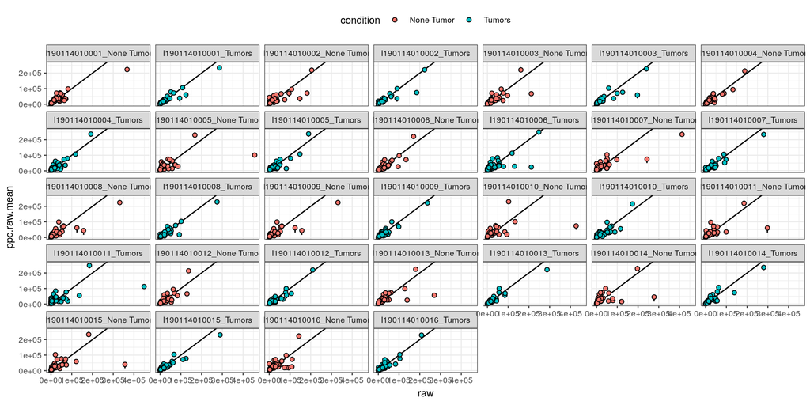

### M1

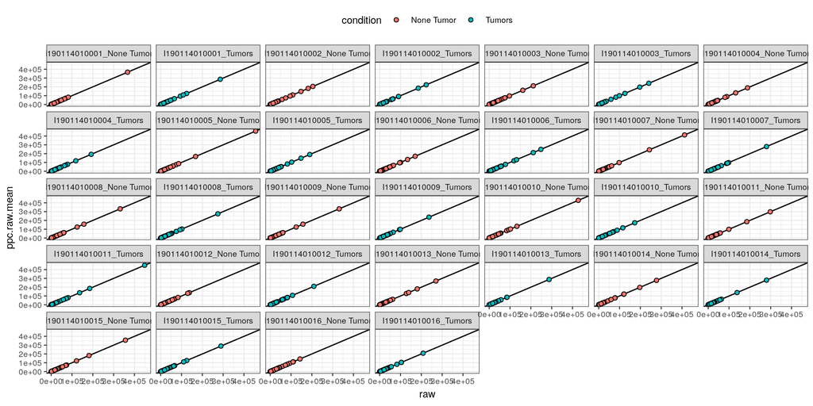

### M2

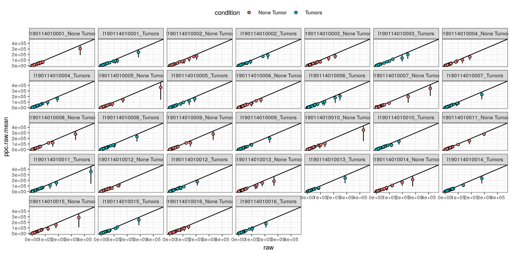

### M3

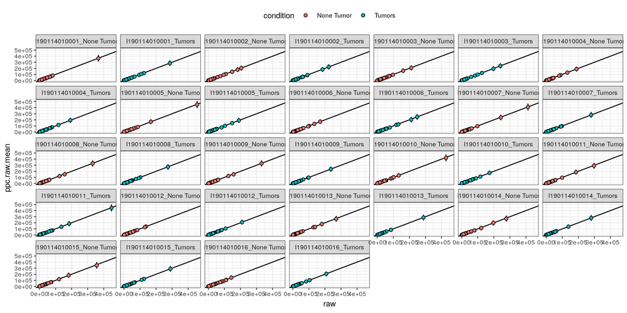

### Errors at a repertoire level

- e[%] = |Yhat[%] - Y[%| or
- e[raw count] = |Yhat[count] - Y[count]|

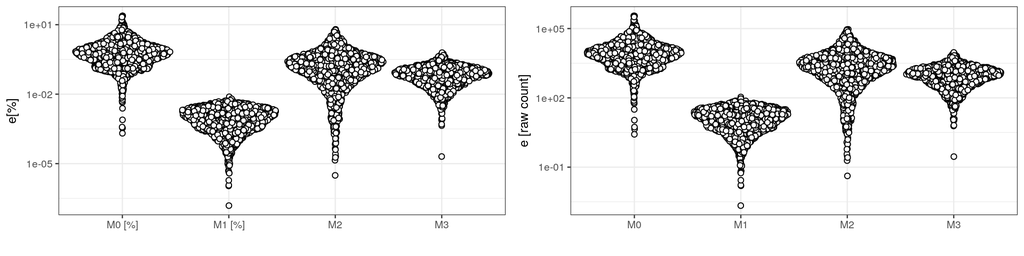

### Errors at a gene level

- raw mean in gene&condition vs ppc mean in gene&condition

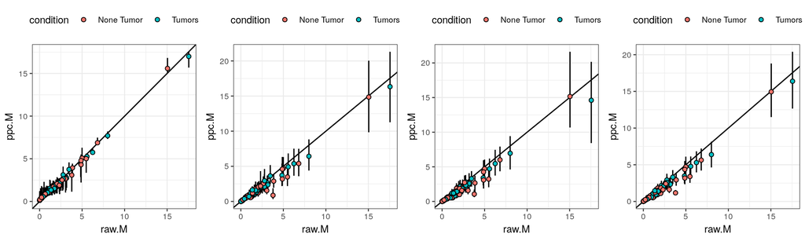